# Owl Limpet Visualization 2023-2024

Cindy Fajardo

2024-10-16

#Welcome In this file, I am creating visualization graphs of population size in the seasons beginning with Fall 2023. It also size distribution of tagged limpets and graphs depicting growth.

#Libraries

```r
library("rerddap")
library(tidyverse)
library("tidync")
library("doParallel")
library(lubridate)
library(patchwork)
library(viridis)
library(here)
library(kableExtra)
library(hrbrthemes)
library(emmeans)
library(agricolae)
library(vegan)
library(performance)
library(broom)
library(car)
library(lme4)
library(lmerTest)
library(pscl)
library(ggridges)
library(devtools)
#library(pairwiseAdonis)
library(FSA)
library(see)
```

#Read in CSV In this chunk, I am reading in the csv’s that are relevant to growth data ONLY

```r
#feb_cnm_shell_length <- read_csv(here("Data","2024_02_CNM_OL_SL_Data.csv"))
master_sl <- read_csv(here("Data","Master_CNM_OL_SL_Data.csv")) %>%
mutate(sex=ifelse(SL_mm>= 50, "female", "male"))
```

#Filtering Data Filtered data to respective month of collection

```r
Winter_data <- filter(master_sl, Season == "Winter",
                      Date != "2023_12")
Fall_data <- master_sl %>%
  select(Season, Date, Plot_Name, SL_mm, Tag_ID, sex) %>%
  filter(Season=="Fall")
Spring_data <- filter(master_sl, Season == "Late_Spring")
March_data <- filter(master_sl, Date =="2024_03")
#June_data <- filter(master_sl, Date == "2024_06")
```

#Simple Statistics In this chunk, I am looking a simple stats like mean, max, min, standard deviation, standard error, variance, etc

```r
Winter_SL_mean <- mean(Winter_data$SL_mm)
Fall_SL_mean <- mean(Fall_data$SL_mm)
Spring_SL_mean <- mean(Spring_data$SL_mm)
#march_SL_mean <- mean(March_data$SL_mm)
#june_SL_mean <- mean(June_data$SL_mm)

max(Fall_data$SL_mm)
```

```
## [1] 77
```

```r
min(Fall_data$SL_mm)
```

```
## [1] 15
```

```r
max(Winter_data$SL_mm)
```

```
## [1] 79
```

```r
min(Winter_data$SL_mm)
```

```
## [1] 15
```

```r
max(Spring_data$SL_mm)
```

```
## [1] 83.68
```

```r
min(Spring_data$SL_mm)
```

```
## [1] 15.11
```

```r
#max(March_data$SL_mm)
#min(March_data$SL_mm)

#max(June_data$SL_mm)
#min(June_data$SL_mm)

median(Winter_data$SL_mm)
```

```
## [1] 48
```

```r
median(Spring_data$SL_mm)
```

```
## [1] 45.16
```

```r
median(Fall_data$SL_mm)
```

```
## [1] 47
```

#Population Shell Length Distribution Graph for Winter In this chunk, I am creating a bar graph showing the shell length distribution for the owl limpets found in my plots in zone 3 for data collection in February 2024

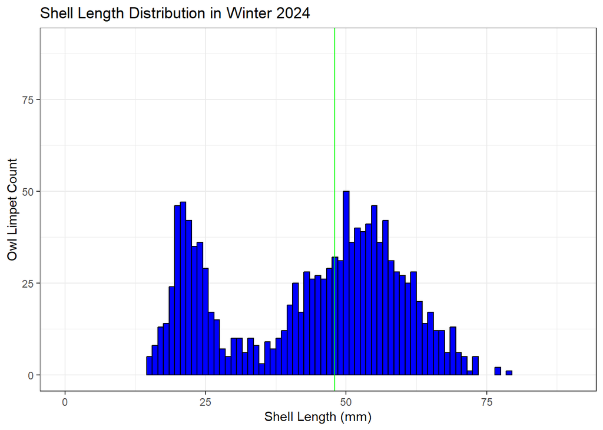

```r
Winter_pop_density <- Winter_data %>%
  filter(Date == "2024_02") %>% #calling df with shell length data
  ggplot( aes(x=SL_mm)) + #Sl on x, I am not selecting y so R can use limpet count for density plot
  geom_bar(fill="blue",#color of bars
           colour="black",#color of bar outline
           alpha= 1,#transparency of bar
           width = 1) + #size of bars
  labs(title = "Shell Length Distribution in Winter 2024",
         x = "Shell Length (mm)",
       y = "Owl Limpet Count")+
  theme(axis.title.y = element_blank(),
        axis.title.x = element_text(size = 10),
        axis.text.x = element_text(size = 9),
        axis.text.y = element_blank())+
  scale_x_continuous(limits = c(0,90))+ #lines I want to show up on x axis
  scale_y_continuous(limits = c(0,90))+ #lines I want to show up on y axis
  geom_vline(xintercept = median(Winter_data$SL_mm),
             colour="green")+ #draw line where average lies on density
  theme_bw()
 Winter_pop_density
```

#Population Shell Length Distribution Graph for Fall

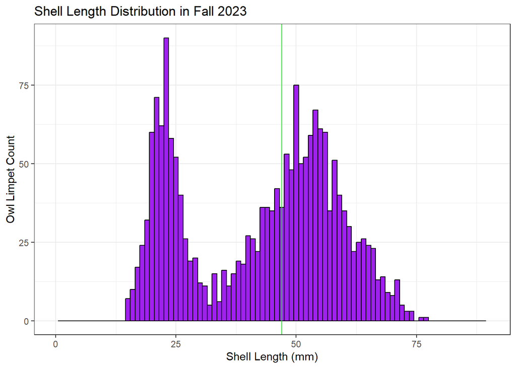

```r
sep_cnm_pop_density <- Fall_data %>% #calling df with shell length data
  ggplot( aes(x=SL_mm)) + #Sl on x, I am not selecting y so R can use limpet count for density plot
  geom_histogram(fill="purple",#color of bars
           colour="black",#color of bar outline
           alpha= 1,#transparency of bar
           binwidth = 1) + #size of bars
  labs(title = "Shell Length Distribution in Fall 2023",
       x = "Shell Length (mm)",
       y = "Owl Limpet Count")+
  theme(axis.title.y = element_blank(),
        axis.title.x = element_text(size = 10),
        axis.text.x = element_text(size = 9),
        axis.text.y = element_blank())+
  scale_x_continuous(limits = c(0,90))+ #lines I want to show up on x axis
  scale_y_continuous(limits = c(0,90))+ #lines I want to show up on y axis
  geom_vline(xintercept = median(Fall_data$SL_mm),
             colour="green")+ #draw line where average lies on density
  theme_bw()
 sep_cnm_pop_density
```

#Population Shell Length Distribution Graph for Spring

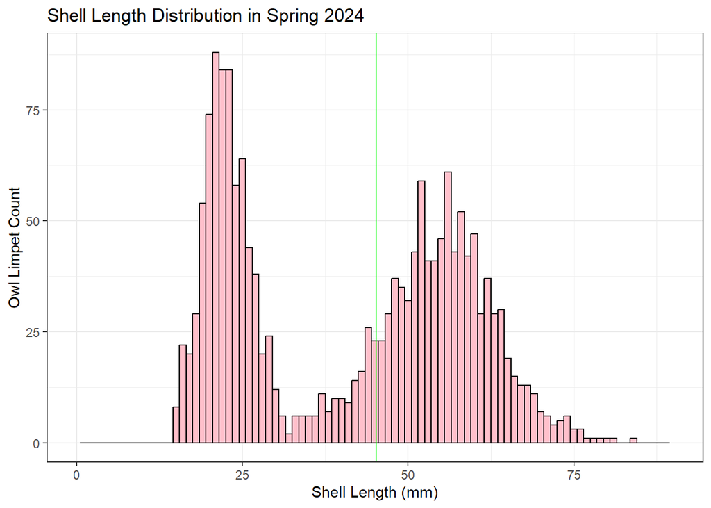

```r
spring_pop_density <- Spring_data %>% #calling df with shell length data
  select(Limpet_No, SL_mm) %>% #selecting limpet number to count and shell length
  ggplot( aes(x=SL_mm)) + #Sl on x, I am not selecting y so R can use limpet count for density plot
  geom_histogram(fill="pink",#color of bars
           colour="black",#color of bar outline
           alpha= 1,#transparency of bar
           binwidth = 1) + #size of bars
  labs(title = "Shell Length Distribution in Spring 2024",
       x = "Shell Length (mm)",
       y = "Owl Limpet Count")+
  theme(axis.title.y = element_blank(),
        axis.title.x = element_text(size = 10),
        axis.text.x = element_text(size = 9),
        axis.text.y = element_blank())+
  scale_x_continuous(limits = c(0,90))+
  geom_vline(xintercept = median(Spring_data$SL_mm),
             colour="green")+ #draw line where average lies on density
  theme_bw()
 spring_pop_density
```

#Size Distribution of Tagged Limpets In Winter In this chunk, I am creating a new data frame with tagged limpets ONLY

```r
Winter_tagged_limpets <- Winter_data %>% #named new data frame using shell length data
  filter(Date != "2023_12",
         Tag_ID != 0) #filtered out non-tagged limpets
Winter_tagged_limpets #calling data frame
```

```
## # A tibble: 29 × 8
##    Season Date    Plot_Name Plot_Side Limpet_No SL_mm Tag_ID sex
##    <chr>  <chr>   <chr>     <chr>         <dbl> <dbl> <chr>  <chr>
##  1 Winter 2024_02 CNM_1     R                47    54 D006   female
##  2 Winter 2024_02 CNM_1     L               212    63 D004   female
##  3 Winter 2024_02 CNM_1     L               225    26 D014   male
##  4 Winter 2024_02 CNM_1     L               273    51 D019   female
##  5 Winter 2024_02 CNM_2     R                67    63 D023   female
##  6 Winter 2024_02 CNM_2     R                71    62 D028   female
##  7 Winter 2024_02 CNM_2     R               156    68 D035   female
##  8 Winter 2024_02 CNM_2     R               157    62 D025   female
##  9 Winter 2024_02 CNM_2     R               158    56 D033   female
## 10 Winter 2024_02 CNM_3     R                 1    77 D062   female
## # ℹ 19 more rows
```

```r
mean(Winter_tagged_limpets$SL_mm)
```

```
## [1] 55.93103
```

#Analysis of Size Distribution Through The Seasons

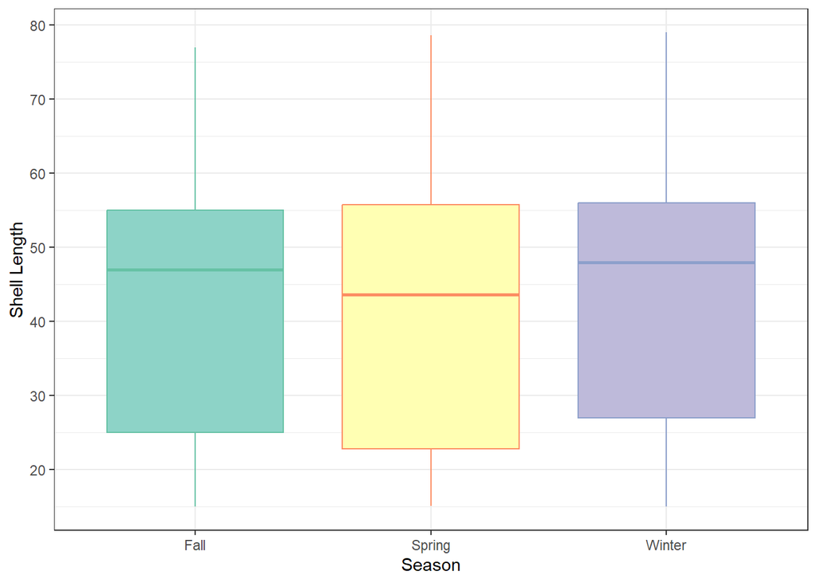

```r
#Data Manipulation
size_dist_all_seasons <-master_sl %>%
  filter(Season!="Spring",
         Date!="2023_12",
         Plot_Name!="CNM_8")

all_seasons_dist_boxplot <- ggplot(size_dist_all_seasons,
                                   aes(x=Season,
                                       y=SL_mm,
                                       color=Season,
                                       fill=Season))+
  geom_boxplot(show.legend = FALSE)+
  labs(x = "Season",
       y ="Shell Length")+
  scale_y_continuous(breaks = c(20,30,40,50,60,70,80,90))+
  scale_x_discrete(labels=c("Fall","Spring","Winter"))+
  scale_color_brewer(palette = "Set2")+
  scale_fill_brewer(palette = "Set3")+
  theme_bw()
all_seasons_dist_boxplot
```

```r
#models
SL_dis_mod <- kruskal.test(SL_mm~Season, data=size_dist_all_seasons)
print(SL_dis_mod)
```

```
##
##  Kruskal-Wallis rank sum test
##
## data:  SL_mm by Season
## Kruskal-Wallis chi-squared = 26.551, df = 2, p-value = 1.716e-06
```

```r
pairwise.wilcox.test(size_dist_all_seasons$SL_mm, size_dist_all_seasons$Season,
                 p.adjust.method = "BH")
```

```
##
##  Pairwise comparisons using Wilcoxon rank sum test with continuity correction
##
## data:  size_dist_all_seasons$SL_mm and size_dist_all_seasons$Season
##
##             Fall    Late_Spring
## Late_Spring 0.00026 -
## Winter      0.06369 3.9e-06
##
## P value adjustment method: BH
```

```r
dunnTest(SL_mm~Season,
         size_dist_all_seasons,
         method="bonferroni")
```

```
##             Comparison         Z      P.unadj        P.adj
## 1   Fall - Late_Spring  3.654458 2.577260e-04 7.731781e-04
## 2        Fall - Winter -1.738321 8.215435e-02 2.464631e-01
## 3 Late_Spring - Winter -4.976127 6.486912e-07 1.946074e-06
```

#Tagged Limpets Shell Length Distribution Graph in Winter This chunk gives population size distribution of limpets in Winter

```r
winter_tagged_distribution <- Winter_tagged_limpets %>% #calling data frame with tagged limpets only
  select(Limpet_No, SL_mm) %>% #selecting limpet number to count and shell length
  ggplot( aes(x=SL_mm)) + #Sl on x, I am not selecting y so R can use limpet count for density plot
  geom_bar(fill="red",#color of bars
           colour="black",#color of bar outline
           alpha= 1,#transparency of bar
           width = 1) + #size of bars
  labs(title = "Size Distribution of Tagged Owl Limpets, Cabrillo National Monument",
       x = "Shell Length (mm)",
       y = "Owl Limpet Count")+
  theme(plot.title = element_text(size = 9),
        axis.title.y = element_text(size = 8),
        axis.title.x = element_text(size = 8),
        axis.text.x = element_text(size = 7),
        axis.text.y = element_text(size = 7))+
  scale_y_continuous(breaks = c(0,2,4,6,8,10,12))+ #lines I want to show up on y axis
  scale_x_continuous(breaks = c(20,40,60,80))+ #lines I want to show up on x axis
  geom_vline(xintercept = mean(Winter_tagged_limpets$SL_mm),
             colour="green")#draw line where average lies on density
winter_tagged_distribution
```

[figure not shown]

#Total number of tagged limpets in Winter

```r
Winter_tagged_limpets %>%
  group_by(Plot_Name) %>%
  count(Tag_ID)
```

```
## # A tibble: 29 × 3
## # Groups:   Plot_Name [6]
##    Plot_Name Tag_ID     n
##    <chr>     <chr>  <int>
##  1 CNM_1     D004       1
##  2 CNM_1     D006       1
##  3 CNM_1     D014       1
##  4 CNM_1     D019       1
##  5 CNM_2     D023       1
##  6 CNM_2     D025       1
##  7 CNM_2     D028       1
##  8 CNM_2     D033       1
##  9 CNM_2     D035       1
## 10 CNM_3     D047       1
## # ℹ 19 more rows
```

#Size Distribution of Tagged Limpets In Fall

```r
Fall_tagged_limpets <- Fall_data %>% #named new data frame using shell length data
  filter(Tag_ID != 0) #filtered out non-tagged limpets
Fall_tagged_limpets #calling data frame
```

```
## # A tibble: 140 × 6
##    Season Date    Plot_Name SL_mm Tag_ID sex
##    <chr>  <chr>   <chr>     <dbl> <chr>  <chr>
##  1 Fall   2023_09 CNM_1        56 D006   female
##  2 Fall   2023_09 CNM_1        54 D002   female
##  3 Fall   2023_09 CNM_1        44 D007   male
##  4 Fall   2023_09 CNM_1        60 D003   female
##  5 Fall   2023_09 CNM_1        65 D008   female
##  6 Fall   2023_09 CNM_1        63 D004   female
##  7 Fall   2023_09 CNM_1        62 D009   female
##  8 Fall   2023_09 CNM_1        50 D010   female
##  9 Fall   2023_09 CNM_1        27 D011   male
## 10 Fall   2023_09 CNM_1        60 D005   female
## # ℹ 130 more rows
```

```r
mean(Fall_tagged_limpets$SL_mm)
```

```
## [1] 48.92143
```

#Tagged Limpets Shell Length Distribution Graph in Fall This chunk gives population size distribution of limpets in September

```r
fall_tagged_distribution <- Fall_tagged_limpets %>% #calling data frame with tagged limpets only
  ggplot( aes(x=SL_mm)) + #Sl on x, I am not selecting y so R can use limpet count for density plot
  geom_bar(fill="brown",#color of bars
           colour="black",#color of bar outline
           alpha= 1,#transparency of bar
           width = 1) + #size of bars
  labs(title = "Size Distribution of Tagged Owl Limpets, Cabrillo National Monument",
       x = "Shell Length (mm)",
       y = "Owl Limpet Count")+
  theme(plot.title = element_text(size = 9),
        axis.title.y = element_text(size = 8),
        axis.title.x = element_text(size = 8),
        axis.text.x = element_text(size = 7),
        axis.text.y = element_text(size = 7))+
  scale_y_continuous(breaks = c(0,2,4,6,8,10,12,14,16))+ #lines I want to show up on y axis
  scale_x_continuous(breaks = c(20,40,60,80))+ #lines I want to show up on x axis
  geom_vline(xintercept = mean(Fall_tagged_limpets$SL_mm),
             colour="green")#draw line where average lies on density
fall_tagged_distribution
```

[figure not shown]

#Size Distribution of Tagged Limpets In Spring (June)

```r
Spring_tagged_limpets <- Spring_data %>% #named new data frame using shell length data
  filter(Tag_ID != 0) #filtered out non-tagged limpets
Spring_tagged_limpets #calling data frame
```

```
## # A tibble: 192 × 8
##    Season      Date    Plot_Name Plot_Side Limpet_No SL_mm Tag_ID sex
##    <chr>       <chr>   <chr>     <chr>         <dbl> <dbl> <chr>  <chr>
##  1 Late_Spring 2024_06 CNM_1     R                12  62.0 D156   female
##  2 Late_Spring 2024_06 CNM_1     R                32  19.5 D185   male
##  3 Late_Spring 2024_06 CNM_1     R                72  54.6 D407   female
##  4 Late_Spring 2024_06 CNM_1     R                73  33.8 D186   male
##  5 Late_Spring 2024_06 CNM_1     R                86  63.5 D166   female
##  6 Late_Spring 2024_06 CNM_1     R                91  61.6 D409   female
##  7 Late_Spring 2024_06 CNM_1     R               108  23.6 D187   male
##  8 Late_Spring 2024_06 CNM_1     R               112  24.6 D410   male
##  9 Late_Spring 2024_06 CNM_1     R               120  55.0 D170   female
## 10 Late_Spring 2024_06 CNM_1     R               139  23.2 D181   male
## # ℹ 182 more rows
```

```r
mean(Spring_tagged_limpets$SL_mm)
```

```
## [1] 50.73307
```

#Tagged Limpets Shell Length Distribution Graph in Spring (June) This chunk gives population size distribution of limpets in Spring

```r
spring_tagged_distribution <- Spring_tagged_limpets %>% #calling data frame with tagged limpets only
  ggplot( aes(x=SL_mm)) + #Sl on x, I am not selecting y so R can use limpet count for density plot
  geom_histogram(fill="orange",#color of bars
           colour="black",#color of bar outline
           alpha= 1,#transparency of bar
           binwidth = 1) + #size of bars
  labs(title = "Size Distribution of Tagged Owl Limpets, Cabrillo National Monument",
       x = "Shell Length (mm)",
       y = "Owl Limpet Count")+
  theme(plot.title = element_text(size = 9),
        axis.title.y = element_text(size = 8),
        axis.title.x = element_text(size = 8),
        axis.text.x = element_text(size = 7),
        axis.text.y = element_text(size = 7))+
  scale_y_continuous(breaks = c(0,2,4,6,8,10))+ #lines I want to show up on y axis
  scale_x_continuous(breaks = c(20,40,60,80))+ #lines I want to show up on x axis
  geom_vline(xintercept = mean(Spring_tagged_limpets$SL_mm),
             colour="green")#draw line where average lies on density
spring_tagged_distribution
```

[figure not shown]

#Size Distribution of Tagged Limpets In early Spring (March)

```r
March_tagged_limpets <- master_sl %>% #named new data frame using shell length data
  filter(Date == "2024_03",
         Tag_ID != 0) #filtered out non-tagged limpets
March_tagged_limpets #calling data frame
```

```
## # A tibble: 354 × 8
##    Season Date    Plot_Name Plot_Side Limpet_No SL_mm Tag_ID sex
##    <chr>  <chr>   <chr>     <chr>         <dbl> <dbl> <chr>  <chr>
##  1 Spring 2024_03 CNM_1     <NA>              1    61 D003   female
##  2 Spring 2024_03 CNM_1     <NA>              2    48 D019   male
##  3 Spring 2024_03 CNM_1     <NA>              3    62 D156   female
##  4 Spring 2024_03 CNM_1     <NA>              4    63 D157   female
##  5 Spring 2024_03 CNM_1     <NA>              5    49 D158   male
##  6 Spring 2024_03 CNM_1     <NA>              6    54 D159   female
##  7 Spring 2024_03 CNM_1     <NA>              7    59 D160   female
##  8 Spring 2024_03 CNM_1     <NA>              8    56 D161   female
##  9 Spring 2024_03 CNM_1     <NA>              9    52 D162   female
## 10 Spring 2024_03 CNM_1     <NA>             10    60 D163   female
## # ℹ 344 more rows
```

```r
mean(March_tagged_limpets$SL_mm)
```

```
## [1] 50.04698
```

#Tagged Limpets Shell Length Distribution Graph in Early Spring (March) This chunk gives population size distribution of limpets in March which was a re-tagging field trip

```r
march_tagged_distribution <- March_tagged_limpets %>% #calling data frame with tagged limpets only
  ggplot( aes(x=SL_mm)) + #Sl on x, I am not selecting y so R can use limpet count for density plot
  geom_histogram(fill="green",#color of bars
           colour="black",#color of bar outline
           alpha= 1,#transparency of bar
           binwidth = 1) + #size of bars
  labs(title = "Size Distribution of Tagged Owl Limpets, Cabrillo National Monument",
       x = "Shell Length (mm)",
       y = "Owl Limpet Count")+
  theme(plot.title = element_text(size = 9),
        axis.title.y = element_text(size = 8),
        axis.title.x = element_text(size = 8),
        axis.text.x = element_text(size = 7),
        axis.text.y = element_text(size = 7))+
  scale_y_continuous(breaks = c(0,5,10,15,20))+ #lines I want to show up on y axis
  scale_x_continuous(breaks = c(20,40,60,80))+ #lines I want to show up on x axis
  geom_vline(xintercept = mean(March_tagged_limpets$SL_mm),
             colour="red")#draw line where average lies on density
march_tagged_distribution
```

[figure not shown]

#Growth Rates In this portion I will begin to visualize growth between the seasons

#Population Average Growth rate of Tagged Limpets from September to February

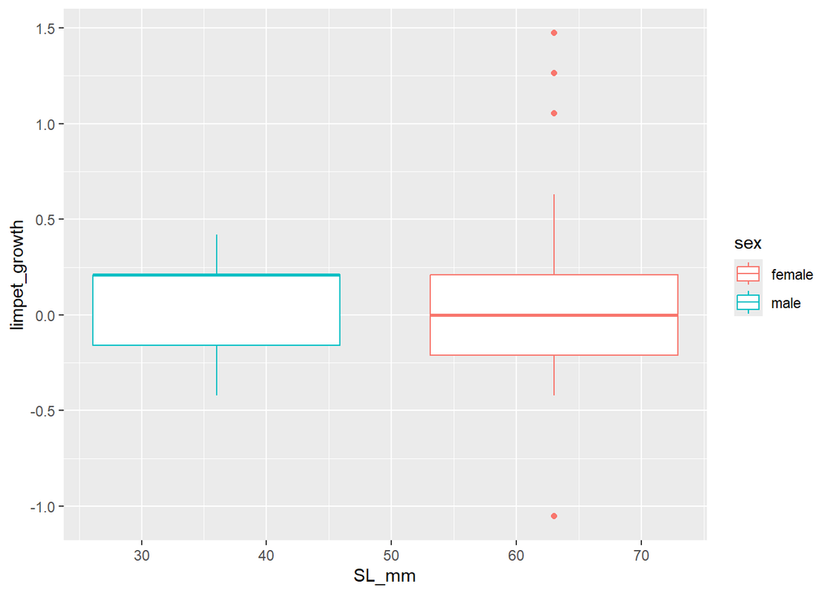

```r
by_sex_data <- master_sl %>%
  filter(Tag_ID!="0") %>%
  group_by(sex, Tag_ID) %>%
  reframe(limpet_growth = (SL_mm[Season=="Winter"]-SL_mm[Season=="Fall"])/4.75) %>%
  left_join(master_sl %>%
              filter(Tag_ID!="0",
                     Season=="Fall") %>%
              select(Tag_ID,SL_mm))

ggplot(by_sex_data, aes(x=SL_mm,
                        y = limpet_growth,
                        color = sex))+
         geom_boxplot()
```

#Density and associated Plots

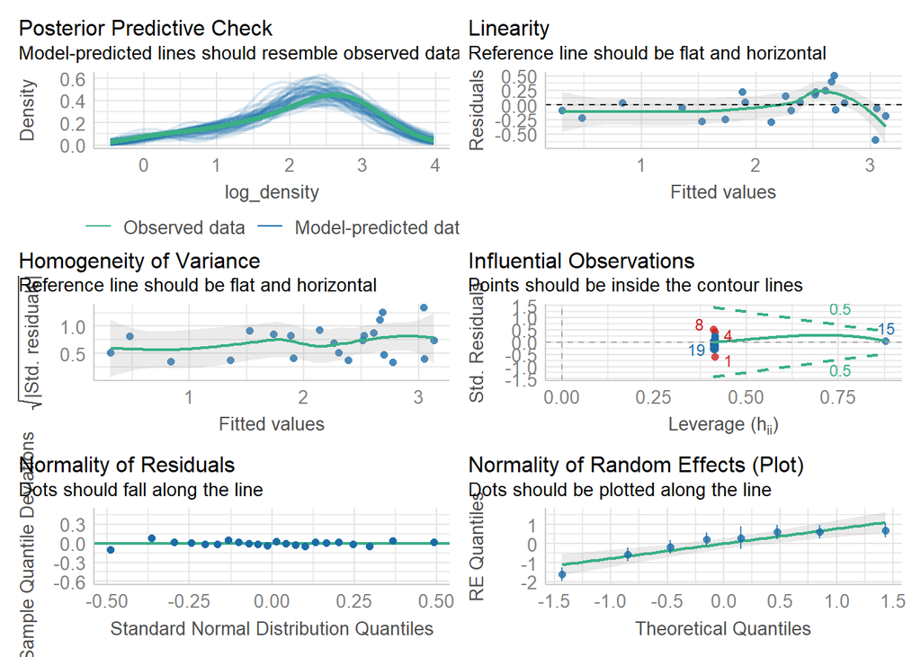

```r
all_seasons_Density_Data <- master_sl %>%
   filter(Season!="Spring", #not including re-tagging event
          Date!="2023_12")  %>% #not including December
   group_by(Season, Plot_Name)%>%
   count()%>%
   mutate(limpet_density_m2 = n/20) %>%
  mutate(Plot = as.factor(Plot_Name)) %>%
  mutate(log_density = log(limpet_density_m2),
         Seasons = as.factor(Season))

 # run model for dependent variable ~ independent, then for normality, etc, interpret model
mod_density_all_seasons <-lmer(log_density~Seasons+(1|Plot), data = all_seasons_Density_Data)
check_model(mod_density_all_seasons)
```

```r
anova(mod_density_all_seasons)
```

```
## Type III Analysis of Variance Table with Satterthwaite's method
##         Sum Sq Mean Sq NumDF  DenDF F value  Pr(>F)
## Seasons 1.0168  0.5084     2 12.277  4.7845 0.02909 *
## ---
## Signif. codes:  0 '***' 0.001 '**' 0.01 '*' 0.05 '.' 0.1 ' ' 1
```

```r
summary(mod_density_all_seasons)
```

```
## Linear mixed model fit by REML. t-tests use Satterthwaite's method [
## lmerModLmerTest]
## Formula: log_density ~ Seasons + (1 | Plot)
##    Data: all_seasons_Density_Data
##
## REML criterion at convergence: 37.1
##
## Scaled residuals:
##      Min       1Q   Median       3Q      Max
## -1.81412 -0.48052 -0.01093  0.52600  1.56618
##
## Random effects:
##  Groups   Name        Variance Std.Dev.
##  Plot     (Intercept) 0.6520   0.8074
##  Residual             0.1063   0.3260
## Number of obs: 22, groups:  Plot, 8
##
## Fixed effects:
##                    Estimate Std. Error      df t value Pr(>|t|)
## (Intercept)          2.4514     0.3135  8.9489   7.818 2.75e-05 ***
## SeasonsLate_Spring  -0.3563     0.1735 12.3424  -2.054   0.0618 .
## SeasonsWinter       -0.5283     0.1742 12.1484  -3.032   0.0103 *
## ---
## Signif. codes:  0 '***' 0.001 '**' 0.01 '*' 0.05 '.' 0.1 ' ' 1
##
## Correlation of Fixed Effects:
##             (Intr) SsnL_S
## SsnsLt_Sprn -0.309
## SeasonsWntr -0.278  0.502
```

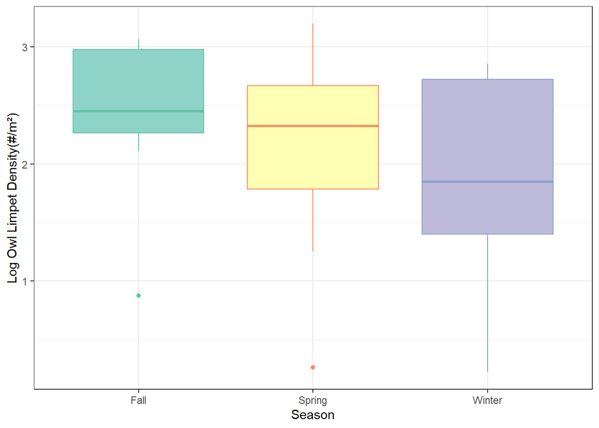

```r
all_seasons_density_plot <- ggplot(all_seasons_Density_Data,
                                   aes(x=Season,
                                       y=log_density,
                                       color=Season,
                                       fill=Season))+
  geom_boxplot(show.legend = FALSE)+
  labs(x = "Season",
       y ="Log Owl Limpet Density(#/m²)")+
  scale_x_discrete(labels=c("Fall","Spring","Winter"))+
  scale_color_brewer(palette = "Set2")+
  scale_fill_brewer(palette = "Set3")+
  theme_bw()

all_seasons_density_plot
```

```r
#Post hoc tests
emmeans(mod_density_all_seasons, list(pairwise~Seasons), adjust = "tukey")
```

```
## $`emmeans of Seasons`
##  Seasons     emmean    SE   df lower.CL upper.CL
##  Fall          2.45 0.314 8.80     1.74     3.16
##  Late_Spring   2.10 0.308 8.26     1.39     2.80
##  Winter        1.92 0.314 8.80     1.21     2.64
##
## Degrees-of-freedom method: kenward-roger
## Confidence level used: 0.95
##
## $`pairwise differences of Seasons`
##  1                    estimate    SE   df t.ratio p.value
##  Fall - Late_Spring      0.356 0.174 12.2   2.047  0.1427
##  Fall - Winter           0.528 0.174 12.0   3.032  0.0262
##  Late_Spring - Winter    0.172 0.174 12.2   0.988  0.5976
##
## Degrees-of-freedom method: kenward-roger
## P value adjustment: tukey method for comparing a family of 3 estimates
```

```r
#TukeyHSD(aov(mod_density_all_seasons, adjust = "tukey"))
#(log_density~Season+(1|Plot), data = all_seasons_Density_Data)

###########################
 #growth_sl <- master_sl %>%
  #filter(Date != "2024_02",
         #Tag_ID !=0) %>%
  #unite(season_tag, c(Season, Tag_ID))
#growth_sl

#initial_new <- (feb_mean - september_mean)
#day_growth_rate <- initial_new/72 #rate per day
#day_growth_rate
#week_growth_rate<- initial_new/19
#week_growth_rate
#month_grow_rate <- initial_new/4.75
#month_grow_rate
```

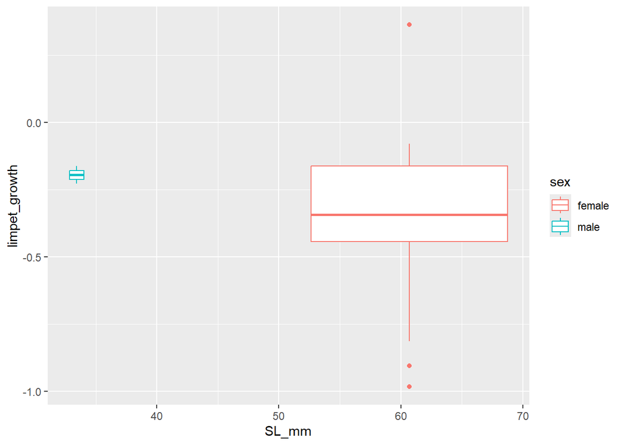

```r
Spring_by_sex_data <- master_sl %>%
  filter(Tag_ID!="0",
         Season!= "Spring") %>%
  group_by(sex, Tag_ID) %>%
  reframe(limpet_growth = (SL_mm[Season=="Winter"]-SL_mm[Season=="Late_Spring"])/4.75) %>%
  left_join(master_sl %>%
              filter(Tag_ID!="0",
                     Season=="Late_Spring") %>%
              select(Tag_ID,SL_mm)) #most values are negative

spring_by_sex_box <- ggplot(Spring_by_sex_data, aes(x=SL_mm,
                        y = limpet_growth,
                        color = sex))+
         geom_boxplot()
spring_by_sex_box
```

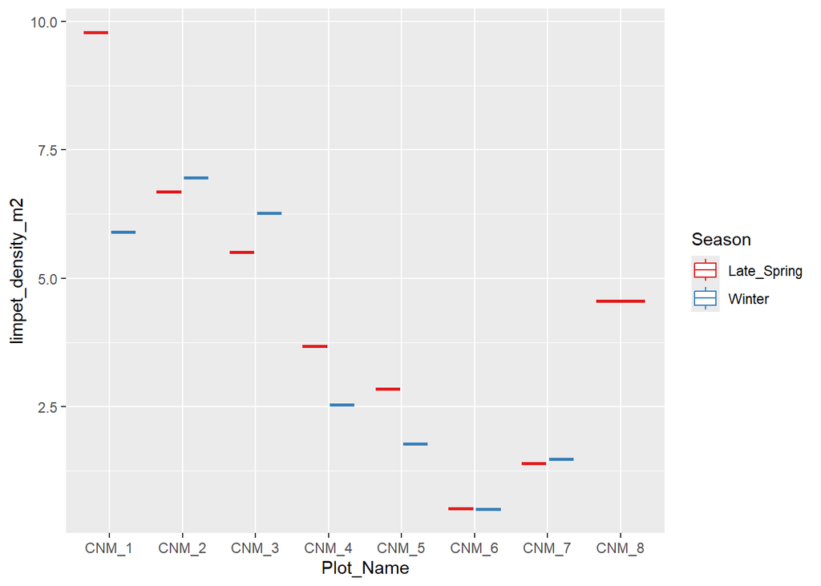

```r
Spring_Density_Data <- master_sl %>%
  filter(Season != "Fall") %>%
  filter(Season != "Spring",
         Date!="2023_12") %>%
   group_by(Season, Plot_Name)%>%
   count()%>%
   mutate(limpet_density_m2 = n/50)

winter_spring_dens_plot <- ggplot(Spring_Density_Data,
       aes(x=Plot_Name,
           y=limpet_density_m2,
           color=Season))+
  geom_boxplot()+
  scale_color_brewer(palette = "Set1")
winter_spring_dens_plot
```

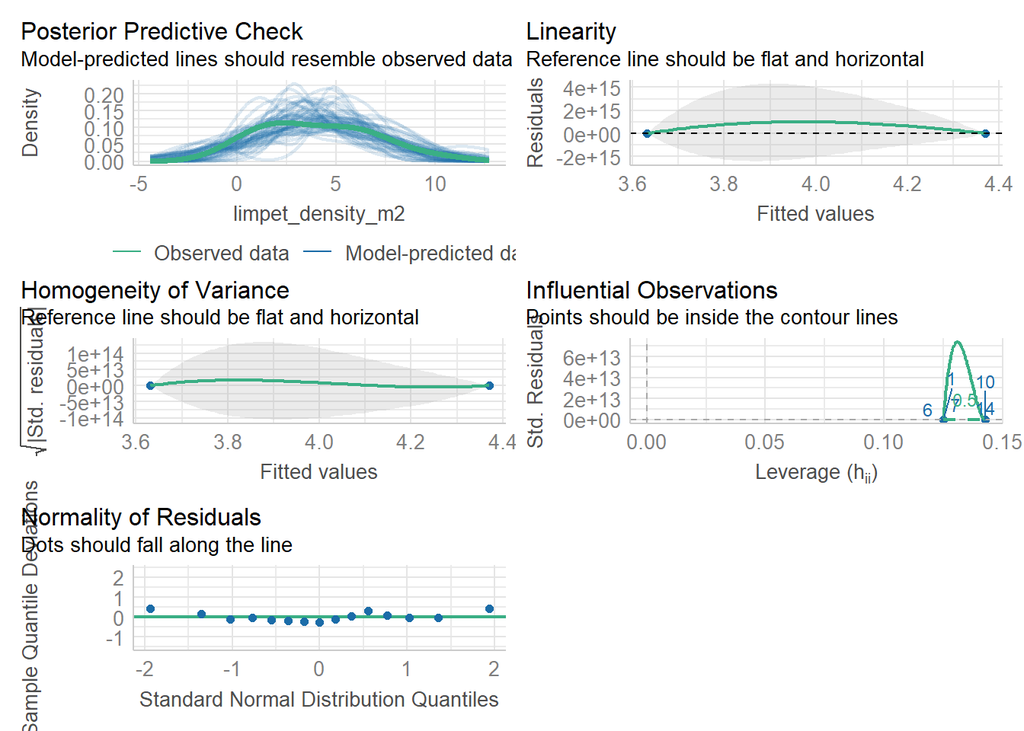

```r
 # run model for dependent variable ~ independent, then for normality, etc, interpret model
mod_density_winter_spring <-lm(limpet_density_m2~Season, data = Spring_Density_Data)
check_model(mod_density_winter_spring)
```

```r
anova(mod_density_winter_spring)
```

```
## Analysis of Variance Table
##
## Response: limpet_density_m2
##           Df  Sum Sq Mean Sq F value Pr(>F)
## Season     1   2.036  2.0365  0.2532 0.6233
## Residuals 13 104.566  8.0436
```

```r
summary(mod_density_winter_spring)
```

```
##
## Call:
## lm(formula = limpet_density_m2 ~ Season, data = Spring_Density_Data)
##
## Residuals:
##    Min     1Q Median     3Q    Max
## -3.850 -2.001 -0.690  2.289  5.410
##
## Coefficients:
##              Estimate Std. Error t value Pr(>|t|)
## (Intercept)    4.3700     1.0027   4.358 0.000775 ***
## SeasonWinter  -0.7386     1.4678  -0.503 0.623260
## ---
## Signif. codes:  0 '***' 0.001 '**' 0.01 '*' 0.05 '.' 0.1 ' ' 1
##
## Residual standard error: 2.836 on 13 degrees of freedom
## Multiple R-squared:  0.0191, Adjusted R-squared:  -0.05635
## F-statistic: 0.2532 on 1 and 13 DF,  p-value: 0.6233
```

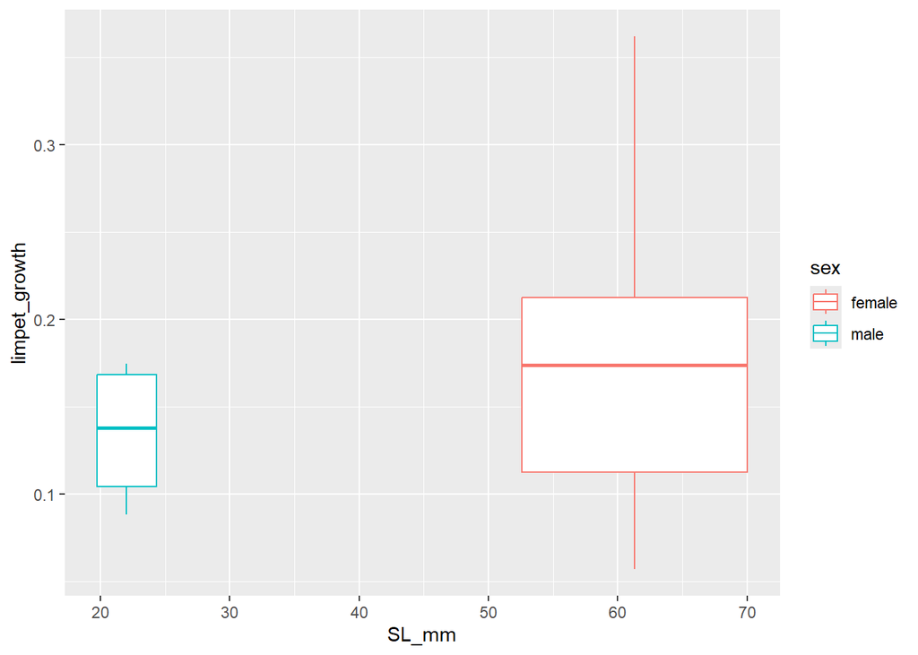

```r
March_by_sex_data <- master_sl %>%
  filter(Tag_ID!="0",
         Season!= "Fall",
         Season!= "Winter") %>%
  group_by(sex, Tag_ID) %>%
  reframe(limpet_growth = (SL_mm[Season=="Spring"]-SL_mm[Season=="Late_Spring"])/4.75) %>%
  left_join(master_sl) %>%
              filter(Tag_ID!="0",
                     Season=="Late_Spring") %>%
              select(Tag_ID,SL_mm, limpet_growth, sex) %>%
  filter(limpet_growth > "0")#most values are negative

march_by_sex_box <- ggplot(March_by_sex_data, aes(x=SL_mm,
                        y = limpet_growth,
                        color = sex))+
         geom_boxplot()
march_by_sex_box
```

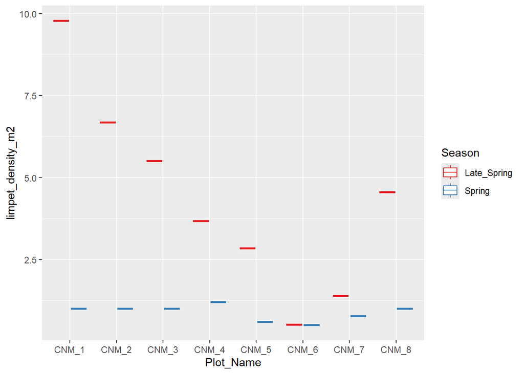

```r
March_Density_Data <- master_sl %>%
  filter(Season != "Fall") %>%
  filter(Season != "Winter") %>%
   group_by(Season, Plot_Name)%>%
   count()%>%
   mutate(limpet_density_m2 = n/50)

March_dens <- ggplot(March_Density_Data,
       aes(x=Plot_Name,
           y=limpet_density_m2,
           color=Season))+
  geom_boxplot()+
  scale_color_brewer(palette = "Set1")
March_dens
```

```r
#March was a retagging event so the density will be significantly smaller as we only measured and recorded 50 or less tagged limpets. Cannot compare March to June
```

######Junk under this line, but potentially useful####### #February Size Density Graph Population size density graph

```r
#p <- Feb_data %>%
  #ggplot( aes(x=SL_mm)) +
   # geom_density(fill = "#FF6666", alpha = 0.6)+
  #labs(title = "February")+
   # theme_ipsum()

#p
```

#February Density Graph Histogram of population size in February

```r
#r <- Feb_data %>%
  #ggplot( aes(x=SL_mm)) +
    #geom_histogram(binwidth = 3, fill = "#70070e", color= "black")+
  #labs(title = "February")+
    theme_ipsum()
```

[output not shown]

[output cut: 254 more lines]

[output not shown]

```r
#r
```

#Septemeber Size Density Graph Density graph of population size in September

```r
#q <- Sep_data %>%
  #ggplot( aes(x=SL_mm)) +
    #geom_density(fill = "#52B4C9", alpha = 0.6)+
  #labs(title = "September")+
    theme_ipsum()
```

[output not shown]

[output cut: 254 more lines]

[output not shown]

```r
#q
```

#Density of September Histogram of graph of population distribution in september

```r
#s <- Sep_data %>%
  #ggplot( aes(x=SL_mm)) +
   # geom_histogram(binwidth = 3, fill = "#bf630d", color= "black")+
  #labs(title = "September")+
    #theme_ipsum()
#s
```

#Patchwork of September and February Shell Length Density graphs of both September and February

```r
#q+p+
 # plot_annotation(title = 'Shell Lenght Density of Owl Limpets in September and February', theme = theme(plot.title = element_text(size = 12)))
```

#Patchwork of Fall and Winter Density Histograms of September and February

```r
#s+r
```

#Boxplot of Raw Density Boxplot of raw density owl limpet population in zone three by season

```r
#sep_feb_master <- filter(master_sl, Date != "2023_12")

#raw_density <- sep_feb_master %>%
 # ggplot(aes(x = as.factor(Season), y = SL_mm, fill = Season))+
  #geom_boxplot()+
  #labs(title = "Raw Density",
   #    fill = "Season",
    #   x = "Season")+
  #theme(plot.title = element_text(size = 8),
   #     axis.title.x = element_text(size = 7),
    #    axis.text.x = element_text(size = 6))
#raw_density
```

#Population Density in Fall and Winter Density graph of owl limpet population per season overlapping each other

```r
#m <- master_sl %>%
 # ggplot( aes(x=SL_mm)) +
  #  geom_density(aes(fill = Season), alpha = 0.6)+
  #labs(title = "Population Density in Fall and Winter",
   #    x = "Shell Length",
    #   y = "Density")+
    #theme_ipsum()

#m
```